# Smart Real Estate Price Analysis.

### Project Domain:- Easte Analytics| Data Analysis | Business Intelligence

### *Project Objective:-*

- The objective of this project is to analyze housing market data to identify key factors influencing house prices, clean real-world messy data containing missing values, and present visual insights that support data-driven decision making for real-estate businesses, buyers, and investors.

### Skills

1. Python
2. Pandas
3. Numpy
4. Data Cleaning & Preprocessing
5. Missing Value Treatment.
6. Exploratory Data Analysis(EDA)
7. Data Visulization (Matplotlib & Seaborn)
8. Business Insight Generation

## Dataset Description

- Dataset Name: King County House Sales Dataset (with missing values)
- Records: 21,613
- Features: 22
- Target Variable: price

## Key Attributes:

- Property size (sqft_living, sqft_lot)
- Structural details (bedrooms, bathrooms, floors)
- Quality indicators (grade, condition)
- Location features (zipcode, waterfront, view)
- Renovation and construction data

## Step 1:- Data Loading & Understanding.

```python
import pandas as pd
df = pd.read_csv("kc_house_data_NaN.csv")
df.head()
```

|  | Unnamed: 0 | id | date | price | bedrooms | bathrooms | sqft_living | sqft_lot | floors | waterfront | ... | grade | sqft_above | sqft_basement | yr_built | yr_renovated | zipcode | lat | long | sqft_living15 | sqft_lot15 |
| --- | --- | --- | --- | --- | --- | --- | --- | --- | --- | --- | --- | --- | --- | --- | --- | --- | --- | --- | --- | --- | --- |
| 0 | 0 | 7129300520 | 20141013T000000 | 221900.0 | 3.0 | 1.00 | 1180 | 5650 | 1.0 | 0 | ... | 7 | 1180 | 0 | 1955 | 0 | 98178 | 47.5112 | -122.257 | 1340 | 5650 |
| 1 | 1 | 6414100192 | 20141209T000000 | 538000.0 | 3.0 | 2.25 | 2570 | 7242 | 2.0 | 0 | ... | 7 | 2170 | 400 | 1951 | 1991 | 98125 | 47.7210 | -122.319 | 1690 | 7639 |
| 2 | 2 | 5631500400 | 20150225T000000 | 180000.0 | 2.0 | 1.00 | 770 | 10000 | 1.0 | 0 | ... | 6 | 770 | 0 | 1933 | 0 | 98028 | 47.7379 | -122.233 | 2720 | 8062 |
| 3 | 3 | 2487200875 | 20141209T000000 | 604000.0 | 4.0 | 3.00 | 1960 | 5000 | 1.0 | 0 | ... | 7 | 1050 | 910 | 1965 | 0 | 98136 | 47.5208 | -122.393 | 1360 | 5000 |
| 4 | 4 | 1954400510 | 20150218T000000 | 510000.0 | 3.0 | 2.00 | 1680 | 8080 | 1.0 | 0 | ... | 8 | 1680 | 0 | 1987 | 0 | 98074 | 47.6168 | -122.045 | 1800 | 7503 |

5 rows × 22 columns

```python
df.shape
```

```
(21613, 22)
```

```python
df.info()
```

```
<class 'pandas.core.frame.DataFrame'>
RangeIndex: 21613 entries, 0 to 21612
Data columns (total 22 columns):
 #   Column         Non-Null Count  Dtype
---  ------         --------------  -----
 0   Unnamed: 0     21613 non-null  int64
 1   id             21613 non-null  int64
 2   date           21613 non-null  object
 3   price          21613 non-null  float64
 4   bedrooms       21600 non-null  float64
 5   bathrooms      21603 non-null  float64
 6   sqft_living    21613 non-null  int64
 7   sqft_lot       21613 non-null  int64
 8   floors         21613 non-null  float64
 9   waterfront     21613 non-null  int64
 10  view           21613 non-null  int64
 11  condition      21613 non-null  int64
 12  grade          21613 non-null  int64
 13  sqft_above     21613 non-null  int64
 14  sqft_basement  21613 non-null  int64
 15  yr_built       21613 non-null  int64
 16  yr_renovated   21613 non-null  int64
 17  zipcode        21613 non-null  int64
 18  lat            21613 non-null  float64
 19  long           21613 non-null  float64
 20  sqft_living15  21613 non-null  int64
 21  sqft_lot15     21613 non-null  int64
dtypes: float64(6), int64(15), object(1)
memory usage: 3.6+ MB
```

```python
df.describe()
```

|  | Unnamed: 0 | id | price | bedrooms | bathrooms | sqft_living | sqft_lot | floors | waterfront | view | ... | grade | sqft_above | sqft_basement | yr_built | yr_renovated | zipcode | lat | long | sqft_living15 | sqft_lot15 |
| --- | --- | --- | --- | --- | --- | --- | --- | --- | --- | --- | --- | --- | --- | --- | --- | --- | --- | --- | --- | --- | --- |
| count | 21613.00000 | 2.161300e+04 | 2.161300e+04 | 21600.000000 | 21603.000000 | 21613.000000 | 2.161300e+04 | 21613.000000 | 21613.000000 | 21613.000000 | ... | 21613.000000 | 21613.000000 | 21613.000000 | 21613.000000 | 21613.000000 | 21613.000000 | 21613.000000 | 21613.000000 | 21613.000000 | 21613.000000 |
| mean | 10806.00000 | 4.580302e+09 | 5.400881e+05 | 3.372870 | 2.115736 | 2079.899736 | 1.510697e+04 | 1.494309 | 0.007542 | 0.234303 | ... | 7.656873 | 1788.390691 | 291.509045 | 1971.005136 | 84.402258 | 98077.939805 | 47.560053 | -122.213896 | 1986.552492 | 12768.455652 |
| std | 6239.28002 | 2.876566e+09 | 3.671272e+05 | 0.926657 | 0.768996 | 918.440897 | 4.142051e+04 | 0.539989 | 0.086517 | 0.766318 | ... | 1.175459 | 828.090978 | 442.575043 | 29.373411 | 401.679240 | 53.505026 | 0.138564 | 0.140828 | 685.391304 | 27304.179631 |
| min | 0.00000 | 1.000102e+06 | 7.500000e+04 | 1.000000 | 0.500000 | 290.000000 | 5.200000e+02 | 1.000000 | 0.000000 | 0.000000 | ... | 1.000000 | 290.000000 | 0.000000 | 1900.000000 | 0.000000 | 98001.000000 | 47.155900 | -122.519000 | 399.000000 | 651.000000 |
| 25% | 5403.00000 | 2.123049e+09 | 3.219500e+05 | 3.000000 | 1.750000 | 1427.000000 | 5.040000e+03 | 1.000000 | 0.000000 | 0.000000 | ... | 7.000000 | 1190.000000 | 0.000000 | 1951.000000 | 0.000000 | 98033.000000 | 47.471000 | -122.328000 | 1490.000000 | 5100.000000 |
| 50% | 10806.00000 | 3.904930e+09 | 4.500000e+05 | 3.000000 | 2.250000 | 1910.000000 | 7.618000e+03 | 1.500000 | 0.000000 | 0.000000 | ... | 7.000000 | 1560.000000 | 0.000000 | 1975.000000 | 0.000000 | 98065.000000 | 47.571800 | -122.230000 | 1840.000000 | 7620.000000 |
| 75% | 16209.00000 | 7.308900e+09 | 6.450000e+05 | 4.000000 | 2.500000 | 2550.000000 | 1.068800e+04 | 2.000000 | 0.000000 | 0.000000 | ... | 8.000000 | 2210.000000 | 560.000000 | 1997.000000 | 0.000000 | 98118.000000 | 47.678000 | -122.125000 | 2360.000000 | 10083.000000 |
| max | 21612.00000 | 9.900000e+09 | 7.700000e+06 | 33.000000 | 8.000000 | 13540.000000 | 1.651359e+06 | 3.500000 | 1.000000 | 4.000000 | ... | 13.000000 | 9410.000000 | 4820.000000 | 2015.000000 | 2015.000000 | 98199.000000 | 47.777600 | -121.315000 | 6210.000000 | 871200.000000 |

8 rows × 21 columns

Objective :-

- Understand Data & its type.
- Identify numerical & categorical columns.
- Dectect missing values.
- understand stat's representation.

## Step 2: Data Cleaning Process

- Removing Irrelevant columns.

```python
df.drop(columns =['Unnamed: 0'], inplace= True)
```

- Missing Data Detection

```python
df.isnull().sum()
```

```
id                0
date              0
price             0
bedrooms         13
bathrooms        10
sqft_living       0
sqft_lot          0
floors            0
waterfront        0
view              0
condition         0
grade             0
sqft_above        0
sqft_basement     0
yr_built          0
yr_renovated      0
zipcode           0
lat               0
long              0
sqft_living15     0
sqft_lot15        0
dtype: int64
```

Observed Missing Columns:-

- Bedrooms
- Bathrooms

## Missing Data Treatment

```python
df['bedrooms'] = df['bedrooms'].fillna(df['bedrooms'].mean())
df['bathrooms'] = df['bathrooms'].fillna(df['bathrooms'].mean())
```

```python
df.isna().sum()
```

```
id               0
date             0
price            0
bedrooms         0
bathrooms        0
sqft_living      0
sqft_lot         0
floors           0
waterfront       0
view             0
condition        0
grade            0
sqft_above       0
sqft_basement    0
yr_built         0
yr_renovated     0
zipcode          0
lat              0
long             0
sqft_living15    0
sqft_lot15       0
dtype: int64
```

## Date Formatting.

```python
df['date'] = pd.to_datetime(df['date'])
```

```python
df['date'].dtype
```

```
dtype('<M8[ns]')
```

## Step 3: Exploratory Data Analysis (EDA)

```python
import matplotlib.pyplot as plt
import seaborn as sns
```

### Q1.What is the distrubution of house prices?

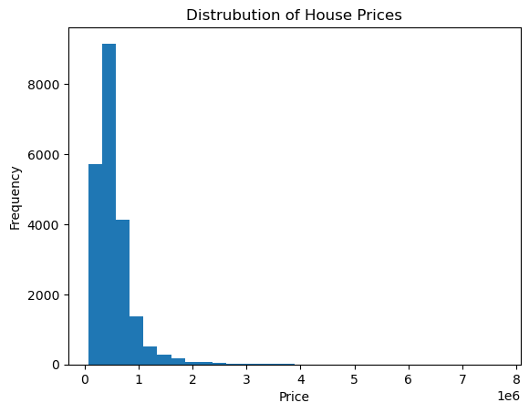

```python
plt.figure()
plt.hist(df['price'], bins=30)
plt.title("Distrubution of House Prices")
plt.xlabel("Price")
plt.ylabel("Frequency")
plt.show()
```

### Analysis :-

- Distrubution is Right Skewed.
- Majority houses are in tha mid price range

### Conclusion.

- Luxury houses are fewer, market is domainated by affordable properties.

### Q2. How does living area affect price?

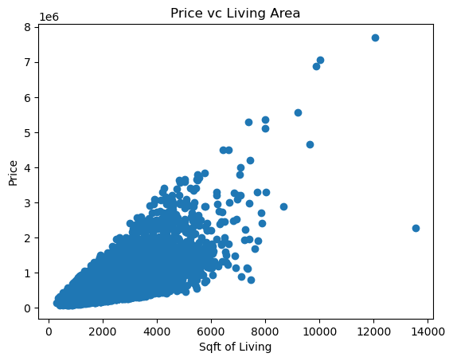

```python
plt.scatter(df['sqft_living'], df['price'])
plt.xlabel("Sqft of Living")
plt.ylabel("Price")
plt.title("Price vc Living Area")
plt.show()
```

## Analysis :-

- Strong positive correlation.

## Conclusion.

- Bigger homes generally cost more.

## Q3. What is the relationship between bedrooms and Price.

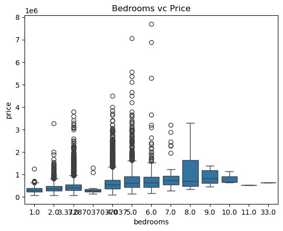

```python
sns.boxplot(x = 'bedrooms', y='price', data=df)
plt.title("Bedrooms vc Price")
plt.show()
```

## Analysis :-

- Price increases till certain bedroom count.

## Conclusion:-

- After 6 bedrooms, price groth slows.

## Q4. Do bathrooms impack house price?

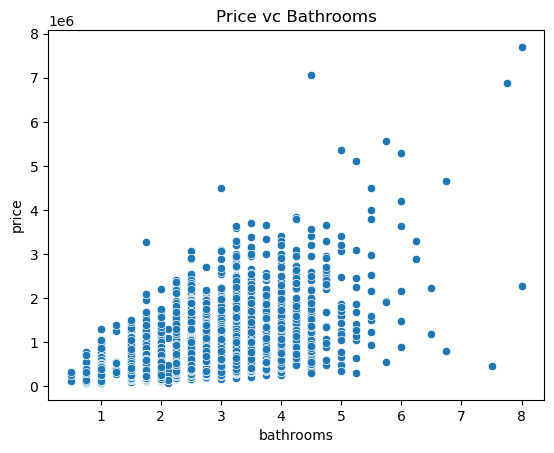

```python
sns.scatterplot(x ='bathrooms', y ='price', data = df)
plt.title("Price vc Bathrooms")
plt.show()
```

## Analysis :-

- Strong impact than bathrooms.

## Conclusion:-

- Bathrooms are more important than bedrooms for pricing.

## Q5.Does waterfront view increase price?

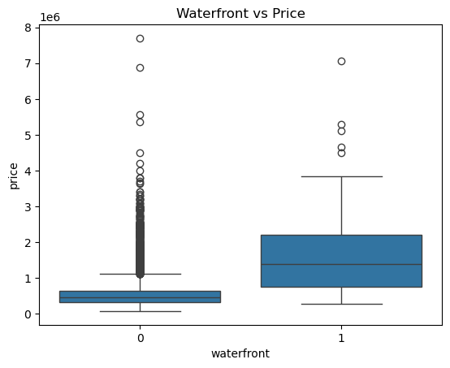

```python
sns.boxplot(x='waterfront', y='price', data=df)
plt.title("Waterfront vs Price")
plt.show()
```

## Analysis

- Waterfront houses are much costlier

## Conclusion

- Waterfront location is a premium feature.

## Q6.What is the correlation among key variables?

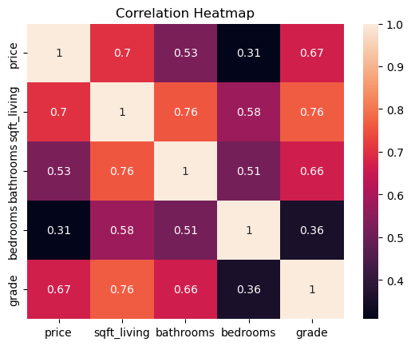

```python
corr = df[['price','sqft_living','bathrooms','bedrooms','grade']].corr()
sns.heatmap(corr, annot=True)
plt.title("Correlation Heatmap")
plt.show()
```

## Analysis

- sqft_living has strongest correlation

## Conclusion

- Living space is the best price predictor.

## Final Conclusion

- This project successfully transformed raw real-estate data with missing values into **clean, structured, and insight-driven analytics**.
- By applying proper data cleaning, missing value treatment, and visualization techniques, meaningful business insights were extracted that can help real-estate companies optimize pricing strategies and assist buyers in making informed decisions.